# Face Generation

In this project, you'll use generative adversarial networks to generate new images of faces.

### Get the Data

You'll be using two datasets in this project:

- MNIST
- CelebA

Since the celebA dataset is complex and you're doing GANs in a project for the first time, we want you to test your neural network on MNIST before CelebA. Running the GANs on MNIST will allow you to see how well your model trains sooner.

If you're using [FloydHub](https://www.floydhub.com/), set `data_dir` to "/input" and use the [FloydHub data ID](http://docs.floydhub.com/home/using_datasets/) "R5KrjnANiKVhLWAkpXhNBe".

```python
data_dir = './data'

# FloydHub - Use with data ID "R5KrjnANiKVhLWAkpXhNBe"
#data_dir = '/input'


"""
DON'T MODIFY ANYTHING IN THIS CELL
"""
import helper

helper.download_extract('mnist', data_dir)
helper.download_extract('celeba', data_dir)
```

```
Downloading mnist: 9.92MB [00:00, 26.2MB/s]
Downloading celeba: 1.44GB [01:04, 22.3MB/s]
```

```
Extracting celeba...
```

## Explore the Data

### MNIST

As you're aware, the [MNIST](http://yann.lecun.com/exdb/mnist/) dataset contains images of handwritten digits. You can view the first number of examples by changing `show_n_images`.

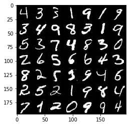

```python
show_n_images = 50

"""
DON'T MODIFY ANYTHING IN THIS CELL
"""
%matplotlib inline
import os
from glob import glob
from matplotlib import pyplot

mnist_images = helper.get_batch(glob(os.path.join(data_dir, 'mnist/*.jpg'))[:show_n_images], 28, 28, 'L')
pyplot.imshow(helper.images_square_grid(mnist_images, 'L'), cmap='gray')
```

### CelebA

The [CelebFaces Attributes Dataset (CelebA)](http://mmlab.ie.cuhk.edu.hk/projects/CelebA.html) dataset contains over 200,000 celebrity images with annotations. Since you're going to be generating faces, you won't need the annotations. You can view the first number of examples by changing `show_n_images`.

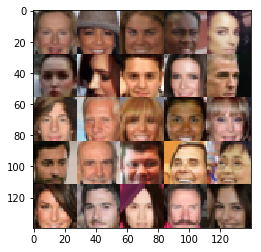

```python
show_n_images = 25

"""
DON'T MODIFY ANYTHING IN THIS CELL
"""
mnist_images = helper.get_batch(glob(os.path.join(data_dir, 'img_align_celeba/*.jpg'))[:show_n_images], 28, 28, 'RGB')
pyplot.imshow(helper.images_square_grid(mnist_images, 'RGB'))
```

## Preprocess the Data

Since the project's main focus is on building the GANs, we'll preprocess the data for you. The values of the MNIST and CelebA dataset will be in the range of -0.5 to 0.5 of 28x28 dimensional images. The CelebA images will be cropped to remove parts of the image that don't include a face, then resized down to 28x28.

The MNIST images are black and white images with a single color channel while the CelebA images have 3 color channels (RGB color channel).

## Build the Neural Network

You'll build the components necessary to build a GANs by implementing the following functions below:

- `model_inputs`
- `discriminator`
- `generator`
- `model_loss`
- `model_opt`
- `train`

### Check the Version of TensorFlow and Access to GPU

This will check to make sure you have the correct version of TensorFlow and access to a GPU

```python
"""
DON'T MODIFY ANYTHING IN THIS CELL
"""
from distutils.version import LooseVersion
import warnings
import tensorflow as tf

# Check TensorFlow Version
assert LooseVersion(tf.__version__) >= LooseVersion('1.0'), 'Please use TensorFlow version 1.0 or newer.  You are using {}'.format(tf.__version__)
print('TensorFlow Version: {}'.format(tf.__version__))

# Check for a GPU
if not tf.test.gpu_device_name():
    warnings.warn('No GPU found. Please use a GPU to train your neural network.')
else:
    print('Default GPU Device: {}'.format(tf.test.gpu_device_name()))
```

```
TensorFlow Version: 1.11.0
Default GPU Device: /device:GPU:0
```

### Input

Implement the `model_inputs` function to create TF Placeholders for the Neural Network. It should create the following placeholders:

- Real input images placeholder with rank 4 using `image_width`, `image_height`, and `image_channels`.
- Z input placeholder with rank 2 using `z_dim`.
- Learning rate placeholder with rank 0.

Return the placeholders in the following the tuple (tensor of real input images, tensor of z data)

```python
import problem_unittests as tests

def model_inputs(image_width, image_height, image_channels, z_dim):
    """
    Create the model inputs
    :param image_width: The input image width
    :param image_height: The input image height
    :param image_channels: The number of image channels
    :param z_dim: The dimension of Z
    :return: Tuple of (tensor of real input images, tensor of z data, learning rate)
    """
    # TODO: Implement Function
    input_image = tf.placeholder(tf.float32, shape=(None, image_width, image_height, image_channels),
                                 name='input_image')
    input_z = tf.placeholder(tf.float32, shape=(None, z_dim), name='input_z')
    learning_rate = tf.placeholder(tf.float32, name='learning_rate')

    return input_image, input_z, learning_rate


"""
DON'T MODIFY ANYTHING IN THIS CELL THAT IS BELOW THIS LINE
"""
tests.test_model_inputs(model_inputs)
```

```
Tests Passed
```

### Discriminator

Implement `discriminator` to create a discriminator neural network that discriminates on `images`. This function should be able to reuse the variables in the neural network. Use [`tf.variable_scope`](https://www.tensorflow.org/api_docs/python/tf/variable_scope) with a scope name of "discriminator" to allow the variables to be reused. The function should return a tuple of (tensor output of the discriminator, tensor logits of the discriminator).

```python
def discriminator(images, reuse=False):
    """
    Create the discriminator network
    :param images: Tensor of input image(s)
    :param reuse: Boolean if the weights should be reused
    :return: Tuple of (tensor output of the discriminator, tensor logits of the discriminator)
    """
    # TODO: Implement Function
    # input image is 28x28x3 for celeb1 and 28x28x1 for mnist
    with tf.variable_scope('discriminator', reuse=reuse):
        x1 = tf.layers.conv2d(images, 64, kernel_size=5, strides=2, padding='same', activation=tf.nn.leaky_relu)
        # not using batchnorm in this layer as suggested by DCGAN paper
        # now is 14x14x64

        x2 = tf.layers.conv2d(x1, 128, kernel_size=5, strides=2, padding='same', activation=None)
        x2 = tf.layers.batch_normalization(x2, training=True)
        x2 = tf.nn.leaky_relu(x2)
        # now is 7x7x128

        x3 = tf.layers.conv2d(x2, 256, kernel_size=5, strides=2, padding='same', activation=None)
        x3 = tf.layers.batch_normalization(x3, training=True)
        x3 = tf.nn.leaky_relu(x3)
        # now is 4x4x256

        flattened = tf.reshape(x3, (-1,4*4*256))

        d_logits = tf.layers.dense(flattened, 1)
        d_out = tf.sigmoid(d_logits)

    return d_out, d_logits


"""
DON'T MODIFY ANYTHING IN THIS CELL THAT IS BELOW THIS LINE
"""
tests.test_discriminator(discriminator, tf)
```

```
Tests Passed
```

### Generator

Implement `generator` to generate an image using `z`. This function should be able to reuse the variables in the neural network. Use [`tf.variable_scope`](https://www.tensorflow.org/api_docs/python/tf/variable_scope) with a scope name of "generator" to allow the variables to be reused. The function should return the generated 28 x 28 x `out_channel_dim` images.

```python
def generator(z, out_channel_dim, is_train=True):
    """
    Create the generator network
    :param z: Input z
    :param out_channel_dim: The number of channels in the output image
    :param is_train: Boolean if generator is being used for training
    :return: The tensor output of the generator
    """
    # TODO: Implement Function

    if is_train:
        reuse = False
    else:
        reuse = True # need to reuse the variables to generate new samples

    with tf.variable_scope('generator', reuse=reuse):
        x1 = tf.layers.dense(z, 3*3*512, activation=tf.nn.leaky_relu)
        x1 = tf.reshape(x1, (-1,3,3,512))
        # now 3x3x512

        x2 = tf.layers.conv2d_transpose(x1, 256, kernel_size=4, strides=2, padding='same', activation=None)
        x2 = tf.layers.batch_normalization(x2, training=is_train)
        x2 = tf.nn.leaky_relu(x2)
        # now 6x6x256

        x3 = tf.layers.conv2d_transpose(x2, 128, kernel_size=4, strides=2, padding='valid', activation=None)
        x3 = tf.layers.batch_normalization(x3, training=is_train)
        x3 = tf.nn.leaky_relu(x3)
        # now 14x14x128

        x4 = tf.layers.conv2d_transpose(x3, out_channel_dim, kernel_size=4, strides=2, padding='same', activation=None)
        g_out = 0.5*tf.nn.tanh(x4) # multiply by 0.5 so that output is between -0.5 and +0.5 (like images)
        # now is 28x28xout_channel_dim

    return g_out


"""
DON'T MODIFY ANYTHING IN THIS CELL THAT IS BELOW THIS LINE
"""
tests.test_generator(generator, tf)
```

```
Tests Passed
```

### Loss

Implement `model_loss` to build the GANs for training and calculate the loss. The function should return a tuple of (discriminator loss, generator loss). Use the following functions you implemented:

- `discriminator(images, reuse=False)`
- `generator(z, out_channel_dim, is_train=True)`

```python
def model_loss(input_real, input_z, out_channel_dim):
    """
    Get the loss for the discriminator and generator
    :param input_real: Images from the real dataset
    :param input_z: Z input
    :param out_channel_dim: The number of channels in the output image
    :return: A tuple of (discriminator loss, generator loss)
    """
    # TODO: Implement Function
    # label smoothing
    smooth = 0.1

    # generator and discriminator outputs
    g_out = generator(input_z, out_channel_dim, is_train=True) # g_out shape is 28x28xout_channel_dim
    d_out_real, d_logits_real = discriminator(input_real, reuse=False)
    d_out_fake, d_logits_fake = discriminator(g_out, reuse=True)

    # labels
    d_labels_real = tf.ones_like(d_out_real) * (1.0 - smooth)
    d_labels_fake = tf.zeros_like(d_out_fake)
    g_labels = tf.ones_like(d_out_fake)

    # losses
    d_loss_real = tf.reduce_mean(
        tf.nn.sigmoid_cross_entropy_with_logits(logits=d_logits_real, labels=d_labels_real))
    d_loss_fake = tf.reduce_mean(
        tf.nn.sigmoid_cross_entropy_with_logits(logits=d_logits_fake, labels=d_labels_fake))
    d_loss = d_loss_real + d_loss_fake # discriminator loss is sum of real and fake losses
    g_loss = tf.reduce_mean(
        tf.nn.sigmoid_cross_entropy_with_logits(logits=d_logits_fake, labels=g_labels))

    return d_loss, g_loss


"""
DON'T MODIFY ANYTHING IN THIS CELL THAT IS BELOW THIS LINE
"""
tests.test_model_loss(model_loss)
```

```
Tests Passed
```

### Optimization

Implement `model_opt` to create the optimization operations for the GANs. Use [`tf.trainable_variables`](https://www.tensorflow.org/api_docs/python/tf/trainable_variables) to get all the trainable variables. Filter the variables with names that are in the discriminator and generator scope names. The function should return a tuple of (discriminator training operation, generator training operation).

```python
def model_opt(d_loss, g_loss, learning_rate, beta1):
    """
    Get optimization operations
    :param d_loss: Discriminator loss Tensor
    :param g_loss: Generator loss Tensor
    :param learning_rate: Learning Rate Placeholder
    :param beta1: The exponential decay rate for the 1st moment in the optimizer
    :return: A tuple of (discriminator training operation, generator training operation)
    """
    # TODO: Implement Function
    # Get all trainable variables, split them in G and D variables
    t_vars = tf.trainable_variables()
    g_vars = [var for var in t_vars if var.name.startswith('generator')]
    d_vars = [var for var in t_vars if var.name.startswith('discriminator')]

    # create optimizer ops for both generator and discriminator
    with tf.control_dependencies(tf.get_collection(tf.GraphKeys.UPDATE_OPS)):
        d_train_op = tf.train.AdamOptimizer(learning_rate=learning_rate, beta1=beta1).minimize(d_loss, var_list=d_vars)
        g_train_op = tf.train.AdamOptimizer(learning_rate=learning_rate, beta1=beta1).minimize(g_loss, var_list=g_vars)

    return d_train_op, g_train_op


"""
DON'T MODIFY ANYTHING IN THIS CELL THAT IS BELOW THIS LINE
"""
tests.test_model_opt(model_opt, tf)
```

```
Tests Passed
```

## Neural Network Training

### Show Output

Use this function to show the current output of the generator during training. It will help you determine how well the GANs is training.

```python
"""
DON'T MODIFY ANYTHING IN THIS CELL
"""
import numpy as np

def show_generator_output(sess, n_images, input_z, out_channel_dim, image_mode):
    """
    Show example output for the generator
    :param sess: TensorFlow session
    :param n_images: Number of Images to display
    :param input_z: Input Z Tensor
    :param out_channel_dim: The number of channels in the output image
    :param image_mode: The mode to use for images ("RGB" or "L")
    """
    cmap = None if image_mode == 'RGB' else 'gray'
    z_dim = input_z.get_shape().as_list()[-1]
    example_z = np.random.uniform(-1, 1, size=[n_images, z_dim])

    samples = sess.run(
        generator(input_z, out_channel_dim, False),
        feed_dict={input_z: example_z})

    images_grid = helper.images_square_grid(samples, image_mode)
    pyplot.imshow(images_grid, cmap=cmap)
    pyplot.show()
```

```python
mnist_dataset = helper.Dataset('mnist', glob(os.path.join(data_dir, 'mnist/*.jpg')))
print(mnist_dataset.shape)
print(mnist_dataset.image_mode)
```

```
(60000, 28, 28, 1)
L
```

### Train

Implement `train` to build and train the GANs. Use the following functions you implemented:

- `model_inputs(image_width, image_height, image_channels, z_dim)`
- `model_loss(input_real, input_z, out_channel_dim)`
- `model_opt(d_loss, g_loss, learning_rate, beta1)`

Use the `show_generator_output` to show `generator` output while you train. Running `show_generator_output` for every batch will drastically increase training time and increase the size of the notebook. It's recommended to print the `generator` output every 100 batches.

```python
def train(epoch_count, batch_size, z_dim, learning_rate, beta1, get_batches, data_shape, data_image_mode):
    """
    Train the GAN
    :param epoch_count: Number of epochs
    :param batch_size: Batch Size
    :param z_dim: Z dimension
    :param learning_rate: Learning Rate
    :param beta1: The exponential decay rate for the 1st moment in the optimizer
    :param get_batches: Function to get batches
    :param data_shape: Shape of the data
    :param data_image_mode: The image mode to use for images ("RGB" or "L")
    """
    # TODO: Build Model
#     saver = tf.train.Saver()
    image_channels = data_shape[3]
    input_real, input_z, lr_tensor = model_inputs(data_shape[1], data_shape[2], image_channels, z_dim)

    d_loss, g_loss = model_loss(input_real, input_z, image_channels)
    d_train_op, g_train_op = model_opt(d_loss, g_loss, learning_rate, beta1)

    losses = []
    steps = 0

    with tf.Session() as sess:
        sess.run(tf.global_variables_initializer())
        for epoch_i in range(epoch_count):
            for batch_images in get_batches(batch_size):
                # TODO: Train Model
                steps += 1

                # Sample random noise for G
                batch_z = np.random.uniform(-1, 1, size=(batch_size, z_dim))

                # run both optimizers
                _ = sess.run(d_train_op,
                             feed_dict={input_real: batch_images, input_z: batch_z, lr_tensor: learning_rate})
                _ = sess.run(g_train_op,
                             feed_dict={input_z: batch_z, input_real: batch_images, lr_tensor: learning_rate})

                if steps%10 == 0:
                    train_loss_d = sess.run(d_loss,
                        feed_dict={input_real: batch_images, input_z: batch_z, lr_tensor: learning_rate})
                    train_loss_g = g_loss.eval(feed_dict={input_z: batch_z, lr_tensor: learning_rate})

                    print("Step {}...".format(steps),
                          "Discriminator Loss: {:.4f}...".format(train_loss_d),
                          "Generator Loss: {:.4f}".format(train_loss_g))
                    # Save losses to view after training
                    losses.append((train_loss_d, train_loss_g))

                if steps%100 == 0:
                    show_generator_output(sess, 20, input_z, image_channels, data_image_mode)

#         saver.save(sess, './checkpoints/generator.ckpt')

    return losses
```

### MNIST

Test your GANs architecture on MNIST. After 2 epochs, the GANs should be able to generate images that look like handwritten digits. Make sure the loss of the generator is lower than the loss of the discriminator or close to 0.

```
Step 10... Discriminator Loss: 0.9951... Generator Loss: 0.9482
Step 20... Discriminator Loss: 2.1894... Generator Loss: 0.2348
Step 30... Discriminator Loss: 2.0277... Generator Loss: 0.3394
Step 40... Discriminator Loss: 1.0748... Generator Loss: 1.1875
Step 50... Discriminator Loss: 1.8576... Generator Loss: 0.3101
Step 60... Discriminator Loss: 0.7462... Generator Loss: 1.4804
Step 70... Discriminator Loss: 0.5424... Generator Loss: 2.3630
Step 80... Discriminator Loss: 0.7313... Generator Loss: 2.3181
Step 90... Discriminator Loss: 0.6463... Generator Loss: 2.8702
Step 100... Discriminator Loss: 0.8692... Generator Loss: 1.7125
```

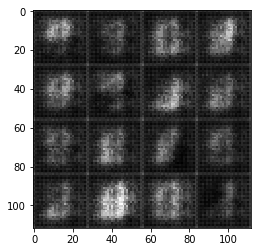

```
Step 110... Discriminator Loss: 0.6983... Generator Loss: 1.9502
Step 120... Discriminator Loss: 0.7353... Generator Loss: 1.5838
Step 130... Discriminator Loss: 0.8991... Generator Loss: 3.2930
Step 140... Discriminator Loss: 1.0176... Generator Loss: 3.7590
Step 150... Discriminator Loss: 0.6335... Generator Loss: 2.6441
Step 160... Discriminator Loss: 0.8775... Generator Loss: 2.9055
Step 170... Discriminator Loss: 1.1336... Generator Loss: 0.8838
Step 180... Discriminator Loss: 0.7407... Generator Loss: 1.8523
Step 190... Discriminator Loss: 0.8221... Generator Loss: 1.7183
Step 200... Discriminator Loss: 0.6850... Generator Loss: 2.1318
```

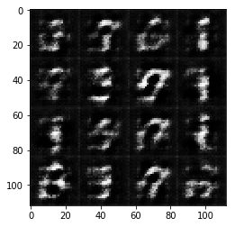

```
Step 210... Discriminator Loss: 0.7503... Generator Loss: 1.6949
Step 220... Discriminator Loss: 0.8457... Generator Loss: 1.7900
Step 230... Discriminator Loss: 0.9320... Generator Loss: 1.3699
Step 240... Discriminator Loss: 0.8183... Generator Loss: 1.5668
Step 250... Discriminator Loss: 0.8625... Generator Loss: 2.3578
Step 260... Discriminator Loss: 0.9785... Generator Loss: 0.9877
Step 270... Discriminator Loss: 0.7979... Generator Loss: 1.5041
Step 280... Discriminator Loss: 0.7763... Generator Loss: 1.7997
Step 290... Discriminator Loss: 0.7909... Generator Loss: 1.6998
Step 300... Discriminator Loss: 0.8345... Generator Loss: 1.4125
```

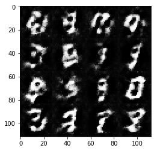

```
Step 310... Discriminator Loss: 0.7626... Generator Loss: 2.1584
Step 320... Discriminator Loss: 0.9603... Generator Loss: 1.0159
Step 330... Discriminator Loss: 1.0032... Generator Loss: 2.2953
Step 340... Discriminator Loss: 0.7701... Generator Loss: 1.5745
Step 350... Discriminator Loss: 0.7237... Generator Loss: 1.9455
Step 360... Discriminator Loss: 0.7829... Generator Loss: 2.0904
Step 370... Discriminator Loss: 0.7624... Generator Loss: 1.3583
Step 380... Discriminator Loss: 0.8462... Generator Loss: 2.3033
Step 390... Discriminator Loss: 0.9486... Generator Loss: 0.9387
Step 400... Discriminator Loss: 0.7434... Generator Loss: 1.3541
```

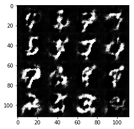

```
Step 410... Discriminator Loss: 0.6900... Generator Loss: 2.4640
Step 420... Discriminator Loss: 0.7299... Generator Loss: 1.4458
Step 430... Discriminator Loss: 0.7236... Generator Loss: 2.2443
Step 440... Discriminator Loss: 0.6640... Generator Loss: 1.9973
Step 450... Discriminator Loss: 0.7244... Generator Loss: 2.2475
Step 460... Discriminator Loss: 0.9766... Generator Loss: 2.8117
Step 470... Discriminator Loss: 0.7625... Generator Loss: 1.3128
Step 480... Discriminator Loss: 0.7012... Generator Loss: 1.4074
Step 490... Discriminator Loss: 0.8854... Generator Loss: 1.0383
Step 500... Discriminator Loss: 0.6810... Generator Loss: 2.0522
```

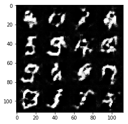

```
Step 510... Discriminator Loss: 1.0626... Generator Loss: 2.8319
Step 520... Discriminator Loss: 0.6655... Generator Loss: 1.9261
Step 530... Discriminator Loss: 0.7692... Generator Loss: 2.1470
Step 540... Discriminator Loss: 0.7567... Generator Loss: 1.9219
Step 550... Discriminator Loss: 1.0927... Generator Loss: 3.0035
Step 560... Discriminator Loss: 0.7515... Generator Loss: 1.4753
Step 570... Discriminator Loss: 0.7323... Generator Loss: 1.3722
Step 580... Discriminator Loss: 0.9104... Generator Loss: 1.1006
Step 590... Discriminator Loss: 0.7503... Generator Loss: 1.6739
Step 600... Discriminator Loss: 0.8705... Generator Loss: 1.9716
```

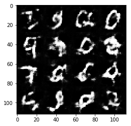

```
Step 610... Discriminator Loss: 1.1555... Generator Loss: 0.6685
Step 620... Discriminator Loss: 1.1562... Generator Loss: 0.6669
Step 630... Discriminator Loss: 0.8709... Generator Loss: 1.0570
Step 640... Discriminator Loss: 0.8550... Generator Loss: 1.2008
Step 650... Discriminator Loss: 0.8316... Generator Loss: 1.1710
Step 660... Discriminator Loss: 0.8218... Generator Loss: 1.6789
Step 670... Discriminator Loss: 0.7444... Generator Loss: 1.7108
Step 680... Discriminator Loss: 0.8591... Generator Loss: 1.0487
Step 690... Discriminator Loss: 1.0311... Generator Loss: 0.7941
Step 700... Discriminator Loss: 0.7785... Generator Loss: 1.5952
```

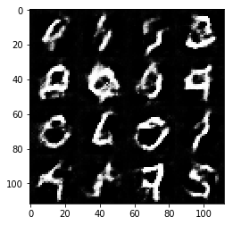

```
Step 710... Discriminator Loss: 0.8123... Generator Loss: 1.9270
Step 720... Discriminator Loss: 0.9804... Generator Loss: 2.4121
Step 730... Discriminator Loss: 1.2314... Generator Loss: 0.6191
Step 740... Discriminator Loss: 1.0649... Generator Loss: 2.3842
Step 750... Discriminator Loss: 0.9437... Generator Loss: 1.0002
Step 760... Discriminator Loss: 0.9395... Generator Loss: 0.9400
Step 770... Discriminator Loss: 0.7956... Generator Loss: 1.8495
Step 780... Discriminator Loss: 0.8247... Generator Loss: 1.7831
Step 790... Discriminator Loss: 0.8236... Generator Loss: 1.2076
Step 800... Discriminator Loss: 0.9199... Generator Loss: 1.7690
```

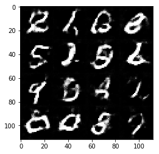

```
Step 810... Discriminator Loss: 0.8070... Generator Loss: 1.5312
Step 820... Discriminator Loss: 1.0649... Generator Loss: 2.6673
Step 830... Discriminator Loss: 0.8539... Generator Loss: 1.4553
Step 840... Discriminator Loss: 1.1937... Generator Loss: 0.6616
Step 850... Discriminator Loss: 0.7933... Generator Loss: 1.5694
Step 860... Discriminator Loss: 0.9147... Generator Loss: 2.0315
Step 870... Discriminator Loss: 0.7036... Generator Loss: 1.4864
Step 880... Discriminator Loss: 0.8711... Generator Loss: 1.0690
Step 890... Discriminator Loss: 0.7975... Generator Loss: 1.4874
Step 900... Discriminator Loss: 0.9371... Generator Loss: 2.2894
```

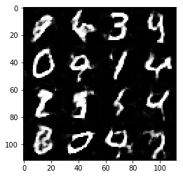

```
Step 910... Discriminator Loss: 0.7726... Generator Loss: 1.6588
Step 920... Discriminator Loss: 0.9710... Generator Loss: 2.2989
Step 930... Discriminator Loss: 1.0936... Generator Loss: 0.7827
```

```python
# with smooth = 0.1
batch_size = 128
z_dim = 100
learning_rate = 0.0002
beta1 = 0.5


"""
DON'T MODIFY ANYTHING IN THIS CELL THAT IS BELOW THIS LINE
"""
epochs = 2

mnist_dataset = helper.Dataset('mnist', glob(os.path.join(data_dir, 'mnist/*.jpg')))
with tf.Graph().as_default():
    train(epochs, batch_size, z_dim, learning_rate, beta1, mnist_dataset.get_batches,
          mnist_dataset.shape, mnist_dataset.image_mode)
```

### CelebA

Run your GANs on CelebA. It will take around 20 minutes on the average GPU to run one epoch. You can run the whole epoch or stop when it starts to generate realistic faces.

```
Step 10... Discriminator Loss: 0.7800... Generator Loss: 1.5252
Step 20... Discriminator Loss: 0.6594... Generator Loss: 5.8917
Step 30... Discriminator Loss: 0.5254... Generator Loss: 2.2761
Step 40... Discriminator Loss: 0.5005... Generator Loss: 6.1853
Step 50... Discriminator Loss: 0.4320... Generator Loss: 4.6185
Step 60... Discriminator Loss: 0.5375... Generator Loss: 6.5468
Step 70... Discriminator Loss: 0.7054... Generator Loss: 2.7273
Step 80... Discriminator Loss: 0.8038... Generator Loss: 1.4823
Step 90... Discriminator Loss: 0.8899... Generator Loss: 1.3446
Step 100... Discriminator Loss: 0.7391... Generator Loss: 1.4694
```

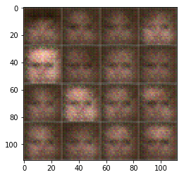

```
Step 110... Discriminator Loss: 0.8409... Generator Loss: 1.0836
Step 120... Discriminator Loss: 0.6783... Generator Loss: 2.4786
Step 130... Discriminator Loss: 0.9546... Generator Loss: 3.1843
Step 140... Discriminator Loss: 0.8899... Generator Loss: 1.1218
Step 150... Discriminator Loss: 0.7102... Generator Loss: 3.3824
Step 160... Discriminator Loss: 0.7629... Generator Loss: 3.2452
Step 170... Discriminator Loss: 0.9346... Generator Loss: 1.3360
Step 180... Discriminator Loss: 0.8724... Generator Loss: 2.2830
Step 190... Discriminator Loss: 1.0891... Generator Loss: 0.9984
Step 200... Discriminator Loss: 0.8518... Generator Loss: 1.3143
```

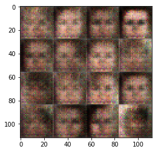

```
Step 210... Discriminator Loss: 0.7099... Generator Loss: 1.8254
Step 220... Discriminator Loss: 0.7978... Generator Loss: 2.0889
Step 230... Discriminator Loss: 0.9224... Generator Loss: 1.8853
Step 240... Discriminator Loss: 1.0032... Generator Loss: 2.2662
Step 250... Discriminator Loss: 0.9477... Generator Loss: 1.3256
Step 260... Discriminator Loss: 0.9559... Generator Loss: 1.8609
Step 270... Discriminator Loss: 0.6843... Generator Loss: 1.8646
Step 280... Discriminator Loss: 0.9314... Generator Loss: 1.2508
Step 290... Discriminator Loss: 0.8235... Generator Loss: 1.6492
Step 300... Discriminator Loss: 1.1379... Generator Loss: 0.8516
```

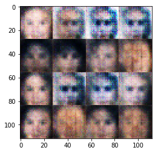

```
Step 310... Discriminator Loss: 1.1373... Generator Loss: 0.7680
Step 320... Discriminator Loss: 0.9456... Generator Loss: 1.2150
Step 330... Discriminator Loss: 0.8645... Generator Loss: 2.2025
Step 340... Discriminator Loss: 0.9913... Generator Loss: 1.4031
Step 350... Discriminator Loss: 0.9423... Generator Loss: 1.7223
Step 360... Discriminator Loss: 0.9103... Generator Loss: 1.2317
Step 370... Discriminator Loss: 1.5501... Generator Loss: 3.1269
Step 380... Discriminator Loss: 0.8975... Generator Loss: 1.8379
Step 390... Discriminator Loss: 0.9250... Generator Loss: 1.3748
Step 400... Discriminator Loss: 0.9291... Generator Loss: 1.2448
```

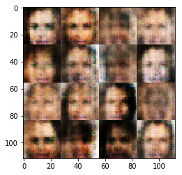

```
Step 410... Discriminator Loss: 0.8548... Generator Loss: 1.3070
Step 420... Discriminator Loss: 0.8805... Generator Loss: 1.6517
Step 430... Discriminator Loss: 1.0142... Generator Loss: 1.6322
Step 440... Discriminator Loss: 0.9061... Generator Loss: 1.4027
Step 450... Discriminator Loss: 0.8919... Generator Loss: 1.2316
Step 460... Discriminator Loss: 1.0258... Generator Loss: 1.5880
Step 470... Discriminator Loss: 1.0375... Generator Loss: 2.1615
Step 480... Discriminator Loss: 0.9584... Generator Loss: 1.8663
Step 490... Discriminator Loss: 0.9559... Generator Loss: 1.9992
Step 500... Discriminator Loss: 0.9648... Generator Loss: 1.1020
```

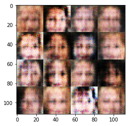

```
Step 510... Discriminator Loss: 1.0110... Generator Loss: 2.6262
Step 520... Discriminator Loss: 1.0890... Generator Loss: 1.0607
Step 530... Discriminator Loss: 1.2379... Generator Loss: 0.8180
Step 540... Discriminator Loss: 1.2152... Generator Loss: 1.5830
Step 550... Discriminator Loss: 1.0076... Generator Loss: 2.0222
Step 560... Discriminator Loss: 1.1136... Generator Loss: 0.9428
Step 570... Discriminator Loss: 0.9374... Generator Loss: 1.3626
Step 580... Discriminator Loss: 1.0278... Generator Loss: 1.4596
Step 590... Discriminator Loss: 1.0336... Generator Loss: 1.1191
Step 600... Discriminator Loss: 0.9115... Generator Loss: 1.6192
```

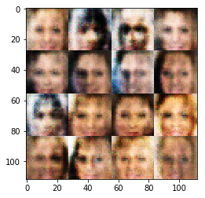

```
Step 610... Discriminator Loss: 1.0336... Generator Loss: 1.9151
Step 620... Discriminator Loss: 1.0241... Generator Loss: 1.1004
Step 630... Discriminator Loss: 1.0707... Generator Loss: 0.8663
Step 640... Discriminator Loss: 1.0593... Generator Loss: 0.9646
Step 650... Discriminator Loss: 1.1376... Generator Loss: 0.8251
Step 660... Discriminator Loss: 1.1286... Generator Loss: 2.0216
Step 670... Discriminator Loss: 1.0277... Generator Loss: 0.9732
Step 680... Discriminator Loss: 0.9719... Generator Loss: 1.1124
Step 690... Discriminator Loss: 1.0643... Generator Loss: 0.9809
Step 700... Discriminator Loss: 1.1232... Generator Loss: 0.9844
```

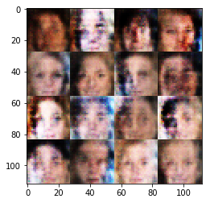

```
Step 710... Discriminator Loss: 1.0979... Generator Loss: 1.2588
Step 720... Discriminator Loss: 0.9846... Generator Loss: 1.1286
Step 730... Discriminator Loss: 1.0405... Generator Loss: 2.0332
Step 740... Discriminator Loss: 1.0986... Generator Loss: 0.8399
Step 750... Discriminator Loss: 0.9914... Generator Loss: 1.1444
Step 760... Discriminator Loss: 1.0092... Generator Loss: 1.0304
Step 770... Discriminator Loss: 1.0518... Generator Loss: 1.0020
Step 780... Discriminator Loss: 0.9362... Generator Loss: 1.2516
Step 790... Discriminator Loss: 1.0641... Generator Loss: 1.1251
Step 800... Discriminator Loss: 1.1691... Generator Loss: 0.8909
```

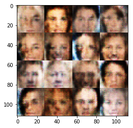

```
Step 810... Discriminator Loss: 1.2667... Generator Loss: 2.1611
Step 820... Discriminator Loss: 1.1393... Generator Loss: 0.8260
Step 830... Discriminator Loss: 1.0925... Generator Loss: 0.8696
Step 840... Discriminator Loss: 1.2137... Generator Loss: 2.1230
Step 850... Discriminator Loss: 0.9833... Generator Loss: 1.8845
Step 860... Discriminator Loss: 0.9706... Generator Loss: 1.8447
Step 870... Discriminator Loss: 0.8218... Generator Loss: 1.4665
Step 880... Discriminator Loss: 1.1897... Generator Loss: 0.8523
Step 890... Discriminator Loss: 0.9155... Generator Loss: 1.7218
Step 900... Discriminator Loss: 1.0406... Generator Loss: 1.4108
```

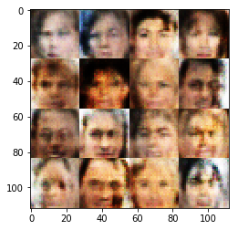

```
Step 910... Discriminator Loss: 1.0393... Generator Loss: 1.0593
Step 920... Discriminator Loss: 1.0714... Generator Loss: 0.8910
Step 930... Discriminator Loss: 1.0256... Generator Loss: 1.0128
Step 940... Discriminator Loss: 1.2087... Generator Loss: 0.8478
Step 950... Discriminator Loss: 1.2415... Generator Loss: 0.6540
Step 960... Discriminator Loss: 0.9396... Generator Loss: 1.3077
Step 970... Discriminator Loss: 1.0749... Generator Loss: 2.0447
Step 980... Discriminator Loss: 1.0001... Generator Loss: 1.3336
Step 990... Discriminator Loss: 1.3539... Generator Loss: 0.5544
Step 1000... Discriminator Loss: 1.0039... Generator Loss: 1.1255
```

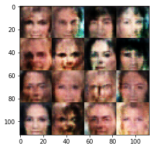

```
Step 1010... Discriminator Loss: 1.0533... Generator Loss: 1.6699
Step 1020... Discriminator Loss: 0.8586... Generator Loss: 1.8119
Step 1030... Discriminator Loss: 0.9746... Generator Loss: 1.7541
Step 1040... Discriminator Loss: 1.2510... Generator Loss: 1.8589
Step 1050... Discriminator Loss: 0.9392... Generator Loss: 1.5431
Step 1060... Discriminator Loss: 1.0841... Generator Loss: 1.0129
Step 1070... Discriminator Loss: 1.0332... Generator Loss: 0.9681
Step 1080... Discriminator Loss: 1.0204... Generator Loss: 0.9460
Step 1090... Discriminator Loss: 0.9730... Generator Loss: 1.1003
Step 1100... Discriminator Loss: 1.1971... Generator Loss: 0.7408
```

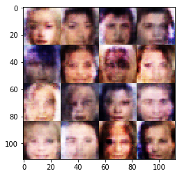

```
Step 1110... Discriminator Loss: 0.9505... Generator Loss: 1.5030
Step 1120... Discriminator Loss: 1.0823... Generator Loss: 0.8288
Step 1130... Discriminator Loss: 1.0115... Generator Loss: 1.0351
Step 1140... Discriminator Loss: 0.8488... Generator Loss: 1.3641
Step 1150... Discriminator Loss: 1.0881... Generator Loss: 1.0422
Step 1160... Discriminator Loss: 0.8128... Generator Loss: 1.3797
Step 1170... Discriminator Loss: 1.1385... Generator Loss: 1.1915
Step 1180... Discriminator Loss: 0.9292... Generator Loss: 1.5114
Step 1190... Discriminator Loss: 0.9462... Generator Loss: 1.2764
Step 1200... Discriminator Loss: 1.0075... Generator Loss: 1.0681
```

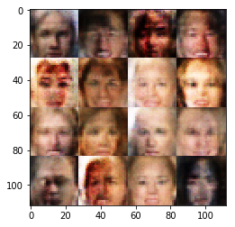

```
Step 1210... Discriminator Loss: 0.9492... Generator Loss: 1.2146
Step 1220... Discriminator Loss: 1.0997... Generator Loss: 0.7921
Step 1230... Discriminator Loss: 0.9243... Generator Loss: 1.5330
Step 1240... Discriminator Loss: 1.0034... Generator Loss: 0.8779
Step 1250... Discriminator Loss: 0.9596... Generator Loss: 1.0149
Step 1260... Discriminator Loss: 1.0840... Generator Loss: 0.9675
Step 1270... Discriminator Loss: 1.0213... Generator Loss: 1.0602
Step 1280... Discriminator Loss: 1.0326... Generator Loss: 1.6392
Step 1290... Discriminator Loss: 1.0061... Generator Loss: 1.8185
Step 1300... Discriminator Loss: 0.9453... Generator Loss: 1.6177
```

[3 more figures not shown]

```
Step 1510... Discriminator Loss: 0.9909... Generator Loss: 2.4893
Step 1520... Discriminator Loss: 1.0660... Generator Loss: 0.8812
Step 1530... Discriminator Loss: 0.9322... Generator Loss: 1.3385
Step 1540... Discriminator Loss: 0.9837... Generator Loss: 1.3050
Step 1550... Discriminator Loss: 1.0220... Generator Loss: 1.3693
Step 1560... Discriminator Loss: 1.0628... Generator Loss: 1.0405
Step 1570... Discriminator Loss: 1.0155... Generator Loss: 1.7857
Step 1580... Discriminator Loss: 1.0221... Generator Loss: 1.0381
```

```python
# with Smooth = 0.1
batch_size = 128
z_dim = 100
learning_rate = 0.0002
beta1 = 0.5


"""
DON'T MODIFY ANYTHING IN THIS CELL THAT IS BELOW THIS LINE
"""
epochs = 1

celeba_dataset = helper.Dataset('celeba', glob(os.path.join(data_dir, 'img_align_celeba/*.jpg')))
with tf.Graph().as_default():
    train(epochs, batch_size, z_dim, learning_rate, beta1, celeba_dataset.get_batches,
          celeba_dataset.shape, celeba_dataset.image_mode)
```

### Submitting This Project

When submitting this project, make sure to run all the cells before saving the notebook. Save the notebook file as "dlnd_face_generation.ipynb" and save it as a HTML file under "File" -> "Download as". Include the "helper.py" and "problem_unittests.py" files in your submission.